# A note about values

Håvard Rue (hrue@r-inla.org) & Sigrunn Holbek Sørbye (sigrunn.sorbye@uit.no)

Dec, 2025

## Introduction

This a short note discussing the argument in , to avoid unfortunate confusion. This is especially an issue for models like , and , which are only defined for integer-valued arguments.

Consider the AR1-model
$$x_t = \phi x_{t-1} + \epsilon_t$$
for $t = 1, 2, \ldots, m$.

In practice, we might use the AR1-model for various sequential indexes, like years, weeks, etc. In these cases, it is naturally to write

```r
y ~ ... + f(year, model = "ar1", ...)
```

where for example is given by

```r
year <- 2000:2025
```

What happens internally, is that the -variable specifies the (time points) at which the AR1-model is defined. So, the variable would be mapped to the $t$-index, which runs from $1$ to $m$.

To be more specific, a mapping between and the $t$-index is defined as

```r
values <- sort(unique(year[!is.na(year)]))
values
```

```
##  [1] 2000 2001 2002 2003 2004 2005 2006 2007 2008 2009 2010 2011 2012 2013 2014
## [16] 2015 2016 2017 2018 2019 2020 2021 2022 2023 2024 2025
```

```r
map.year.to.t <- function(year, values) {
    a <- numeric(length(year))
    for(i in seq_along(year))
        a[i] = which(year[i] == values)
    return (a)
}
yy <- c(2000, 2020, 2025)
print(cbind(year=yy, t=map.year.to.t(yy, values)))
```

```
##      year  t
## [1,] 2000  1
## [2,] 2020 21
## [3,] 2025 26
```

An unfortunate consequence is that if some years are missing, then “confusing” things happen. Suppose, we do not have obsevations for some years,

```r
year <- c(2000:2020, 2023:2025)
```

Then the above mapping still applies but with

```r
values <- sort(unique(year[!is.na(year)]))
values
```

```
##  [1] 2000 2001 2002 2003 2004 2005 2006 2007 2008 2009 2010 2011 2012 2013 2014
## [16] 2015 2016 2017 2018 2019 2020 2023 2024 2025
```

in which the years 2021 and 2022 are missing. The internal mapping now gives

```r
yy <- c(2000, 2020, 2025)
print(cbind(year = yy, t = map.year.to.t(yy, values)))
```

```
##      year  t
## [1,] 2000  1
## [2,] 2020 21
## [3,] 2025 24
```

Note that for $=2025$ the index $t$ is now 24 and not 26 as earlier. This implies that the correlation between year 2020 and 2023 is $\phi$ while it was $\phi^3$ as before. Often, this is not what we expect to happen.

Another case is when the argument denote non-integers, like

```r
time <- c(1.1, 2.2, 3.3, 4.4, 10.0)
```

A call using would run, but will be mapped to the discrete indexes $1, \ldots, 5$. This is because the models are defined on integers and cannot handle irregular locations.

We can ensure consistent behaviour by adding the argument to , specifying for which indexes the model is defined, like

```r
y ~ ... + f(year, model = "ar1", values = 2000:2025)
```

or, if we want predictions for additional years,

```r
y ~ ... + f(year, model = "ar1", values = 1990:2035)
```

In this case, the are defined by the corresponding named argument and not by the variable as before

```r
values <- sort(unique(values[!is.na(values)]))
```

The requirement for is now that these are either -values or a subset of the defined .

## An example

This is a simple simulated example demonstrating the issue about , having missing observations.

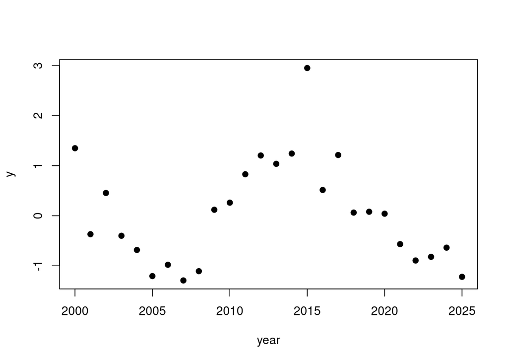

```r
year <- 2000:2025
n <- length(year)
phi <- 0.9
phi.intern <- inla.models()$latent$ar1$hyper$theta2$to.theta(phi)
x <- scale(arima.sim(n, model=list(ar=phi)))
s <- 0.3
y <- x + rnorm(n, sd=s)
plot(year, y, pch=19)
```

Let us fit an AR1 model

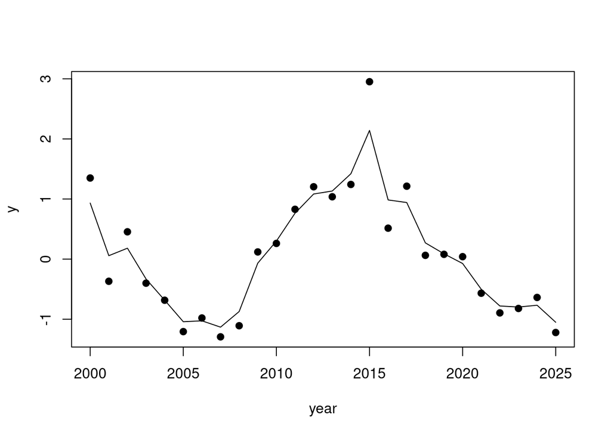

```r
r <- inla(y ~ -1 + f(year, model="ar1",
                     hyper = list(prec = list(initial=0,
                                              fixed=TRUE),
                                  rho = list(initial=phi.intern,
                                             fixed=TRUE))),
        family="gaussian",
        control.family = list(hyper = list(
                                  prec = list(initial=log(1/s^2),
                                  fixed = TRUE))),
        data = data.frame(y, year))
plot(year, y, pch=19)
lines(year, r$summary.random$year$mean)
```

Assume is missing, then we will get the wrong results by removing from the data, because are not given (hence is removed as well).

```r
## this is correct
y[10] <- NA
r <- inla(y ~ -1 + f(year, model="ar1",
                     hyper = list(prec = list(initial=0,
                                              fixed=TRUE),
                                  rho = list(initial=phi.intern,
                                             fixed=TRUE))),
        family="gaussian",
        control.family = list(hyper = list(
                                  prec = list(initial=log(1/s^2),
                                  fixed = TRUE))),
        data = data.frame(y, year))  ## missing data included

## this is wrong
rr <- inla(y ~ -1 + f(year, model="ar1",
                     hyper = list(prec = list(initial=0,
                                              fixed=TRUE),
                                  rho = list(initial=phi.intern,
                                             fixed=TRUE))),
        family="gaussian",
        control.family = list(hyper = list(
                                  prec = list(initial=log(1/s^2),
                                  fixed = TRUE))),
        data = data.frame(y, year)[-10,]) ## missing data removed
## we compare the results
r$mlik - rr$mlik
```

```
##                                           [,1]
## log marginal-likelihood (integration) 1.117952
## log marginal-likelihood (Gaussian)    1.117952
```

If we add , then we get the correct result when we remove missing data.

```r
rrr <- inla(y ~ -1 + f(year, model="ar1",
                      values = 2000:2025,  ## values added
                      hyper = list(prec = list(initial=0,
                                              fixed=TRUE),
                                  rho = list(initial=phi.intern,
                                             fixed=TRUE))),
        family="gaussian",
        control.family = list(hyper = list(
                                  prec = list(initial=log(1/s^2),
                                  fixed = TRUE))),
        data = data.frame(y, year)[-10,]) ## missing data removed
## we compare the results
r$mlik - rrr$mlik
```

```
##                                               [,1]
## log marginal-likelihood (integration) 2.842171e-14
## log marginal-likelihood (Gaussian)    2.842171e-14
```

## Another example

We can extend the range using , to get predictions.

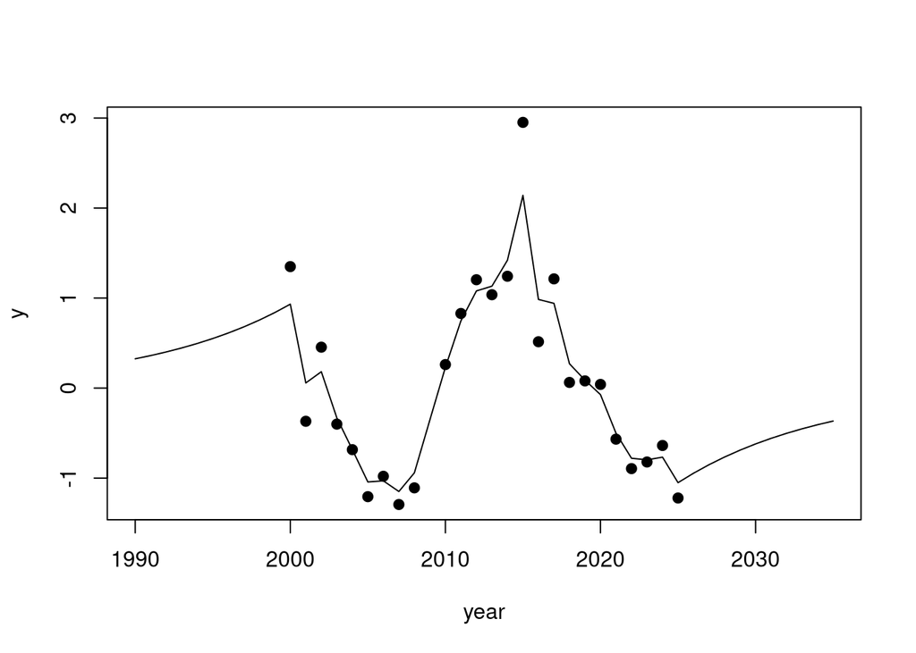

```r
values <- 1990:2035
r <- inla(y ~ -1 + f(year, model="ar1",
                     values = values,  ## values added
                     hyper = list(prec = list(initial=0,
                                              fixed=TRUE),
                                  rho = list(initial=phi.intern,
                                             fixed=TRUE))),
        family="gaussian",
        control.family = list(hyper = list(
                                  prec = list(initial=log(1/s^2),
                                  fixed = TRUE))),
        data = list(y=y, year=year, values=values))
plot(year, y, pch=19, xlim=range(values))
lines(values, r$summary.random$year$mean)
```